# Lab2

Jack Schwarz

2020-09-04

# Tasks

## Task 1

```r
getwd()
```

```
## [1] "/Users/jack/Programming/Classes/MATH4753/Lab 2"
```

## Task 2

```r
epas <- read.csv("EPAGAS.csv")
head(epas)
```

```
##    MPG
## 1 36.3
## 2 41.0
## 3 36.9
## 4 37.1
## 5 44.9
## 6 36.8
```

## Task 3

```r
mpg <- as.vector(epas['MPG'])
head(mpg)
```

```
##    MPG
## 1 36.3
## 2 41.0
## 3 36.9
## 4 37.1
## 5 44.9
## 6 36.8
```

```r
e <- epas$MPG
z <- (e-mean(e))/sd(e)
head(z)
```

```
## [1] -0.28702628  1.65681163 -0.03887676  0.04383975  3.26978352 -0.08023501
```

1. Based on the above z-score, $\overline{z}$ is the following:

```r
round(mean(z), digits=3)
```

```
## [1] 0
```

2. The Standard Deviation of $z$ is:

```r
sd(z)
```

```
## [1] 1
```

3. Possible outliers of $z$:

```r
po = e[abs(z)>=2 & abs(z)<= 3]
```

4. Defined outliers of $z$:

```r
do = e[abs(z) > 3]
```

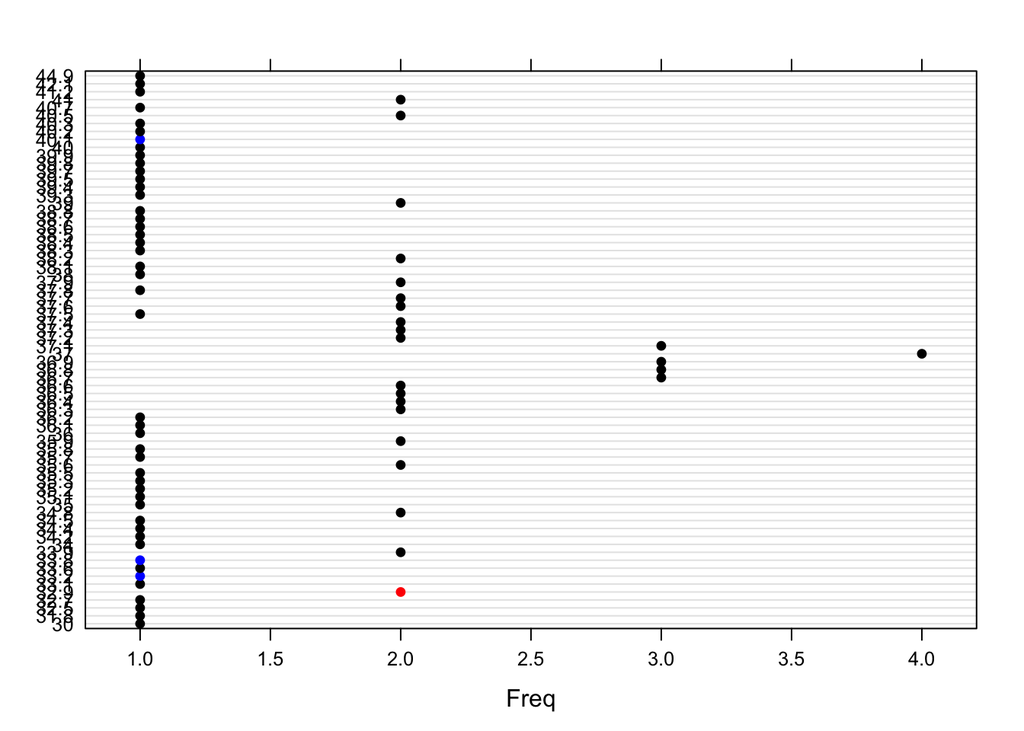

```r
gcol = ifelse(abs(z)>3, "Red",
        ifelse(abs(z)>=2 &abs(z)<=3,"Blue", "Black"))

dotplot(mpg,col=gcol)
```

## Task 4

1. Below is a boxplot of the ‘mpg’ variable

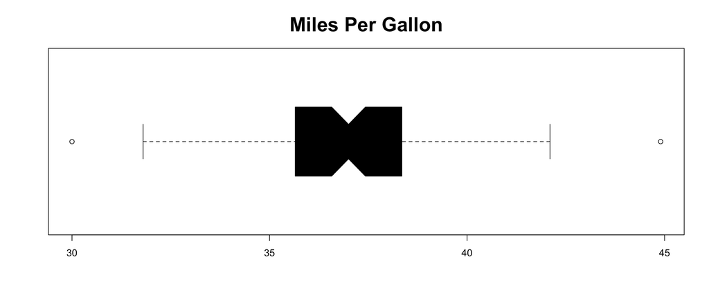

```r
boxplot(mpg, col="black", notch=TRUE, horizontal=TRUE, main="Miles Per Gallon", cex.main=2)
```

2. By Chebyshev’s theorem, the proportion of data within 2 standard deviations of the mean of MPG is at least
   $$\frac{3}{4}$$
3. Below is the actual proportion within 2 standard deviations of the mean

```r
fractions(length(e[abs(z)<2])/length(e))
```

```
## [1] 24/25
```

4. Chebyshev’s estimate is somewhat to the actual proportion found within 2 standard deviations of the mean. As Chebyshev’s states that the expected proportion is *at least*
   $$\frac{3}{4}$$
   the actual number falls in line with this theorem. However this may not be the most exact estimate and Chebyshev’s does not completely agree with the actual data.
5. The Empirical rules states that within 2 standard deviations of the mean, the proportion is
   $$95\%$$
   or
   $$\frac{19}{20}$$
   or
   $$.95$$

```r
length(e[abs(z)<2])/length(e)
```

```
## [1] 0.96
```

7. The Empirical rule estimated that 95% of the data would fall within 2 standard deviations of the mean. The actual data shows that 96% of the data falls within his range. As this is a diference of .01, this shows the Empirical rule is within the acceptable margin for an estimate, and is therefore valid in this case.